# Dureau model

Edwin van Leeuwen

# Introduction

This example is a re-implementation of the model first presented by Dureau, Kalogeropoulos, and Baguelin (2013). The pandemic influenza epidemic in 2009 in the UK exhibited two waves, which is highly unusual and the study explored whether this could be explained by changes in the transmission rate over time, due to school holidays. They explored a number of models. In this example we will explore their simplest model. The data used was a weekly time-series of the GP consultations in the UK during the 2009 pandemic.

# Model

The model is borrowed from the original study (Dureau, Kalogeropoulos, and Baguelin 2013). The modelled states are: susceptibles ($S$), exposed ($E$), infected ($I$) and recovered ($R$).

$$\begin{align}\begin{split}
\frac{\mathrm{d}S}{\mathrm{d}t} & = - \beta S(t) \frac{I(t)}{N}\\
\frac{\mathrm{d}E}{\mathrm{d}t} & = \beta S(t) \frac{I(t)}{N} - k E(t)\\
\frac{\mathrm{d}I}{\mathrm{d}t} & = k E(t) - \gamma I(t)\\
\frac{\mathrm{d}R}{\mathrm{d}t} & = \gamma I(t)\\
\frac{\mathrm{d}Z}{\mathrm{d}t} & = k E(t) - Z \delta(t \bmod 7)\\
\frac{\mathrm{d}x}{\mathrm{d}t} & = \sigma \mathrm{dW}\\
\beta & = e^{x(t)}
\end{split}\end{align}$$
with $Z$ the cumulative number of new infections per seven days and $x$ the log transformed transmissibility. $\delta(t \bmod 7)$ is the Dirac delta function, which causes $Z$ to reset to zero when $t \bmod 7 = 0$, i.e., every seven days. The latent and infectious periods correspond to $\frac1k$ and $\frac1{\gamma}$, respectively. The amplitude of the stochasticity in the transmission rate is controlled by the parameter $\sigma$.

## Likelihood

The likelihood of the data was assumed to be log-normally distributed in the original manuscript. Not everyone infected ends up visiting a GP, either due to asymptomatic infections or the patients’ likelihood to consult a GP. Therefore the authors assumed that the true incidence was 10 times higher than the number of GP visits. This correction was further supported by serological survey (see the original study for further details (Dureau, Kalogeropoulos, and Baguelin 2013)).

$$\mathcal{L}(Z|y_i, \tau) = \mathcal{N}(\log(y_i), \log (Z/10), \tau)$$

## Priors

```r
library(rbi)
library(rbi.helpers)
# Load the data
v <- read.csv("assets/andre_estimates_21_02.txt", sep  = "\t") %>%
  rowSums()
y <- data.frame(value = v) %>%
  mutate(time = seq(7, by = 7, length.out = n())) %>%
  dplyr::select(time, value)
ncores <- 8
minParticles <- max(ncores, 16)
```

```r
model_str <- "
model dureau {
  obs y

  state S
  state E
  state I
  state R
  state x

  state Z

  input N
  param k
  param gamma
  param sigma // Noise driver
  param E0
  param I0
  param R0
  param x0
  param tau

  sub parameter {
    k ~ truncated_gaussian(1.59, 0.02, lower = 0) // k is the period here, not the rate, i.e. 1/k is the rate
    gamma ~ truncated_gaussian(1.08, 0.075, lower = 0) // gamma is the period, not the rate
    sigma ~ uniform(0,1)
    x0 ~ uniform(-5,2)
    I0 ~ uniform(-16, -9)
    E0 ~ uniform(-16, -9)
    R0 ~ truncated_gaussian(0.15, 0.15, lower = 0, upper = 1)
    tau ~ uniform(0, 1)
  }

  sub initial {
    S <- N
    R <- R0*S
    S <- S - R

    E <- exp(E0 + log(S))
    S <- S - E
    I <- exp(I0 + log(S))
    S <- S - I
    x <- x0
    Z <- 0
  }

  sub transition(delta = 1) {
    Z <- ((t_now) % 7 == 0 ? 0 : Z)
    noise e
    e ~ wiener()
    ode(alg = 'RK4(3)', h = 1.0, atoler = 1.0e-3, rtoler = 1.0e-8) {
      dx/dt = sigma*e
      dS/dt = -exp(x)*S*I/N
      dE/dt = exp(x)*S*I/N - E/k
      dI/dt = E/k-I/gamma
      dR/dt = I/gamma
      dZ/dt = E/k
    }
  }

  sub observation {
    y ~ log_normal(log(max(Z/10.0, 0)), tau)
  }

  sub proposal_parameter {
    k ~ gaussian(k, 0.005)
    sigma ~ gaussian(sigma, 0.01)
    gamma ~ gaussian(gamma, 0.01)
    x0 ~ gaussian(x0, 0.05)
    E0 ~ gaussian(E0, 0.05)
    I0 ~ gaussian(I0, 0.05)
    R0 ~ gaussian(R0, 0.05)
    tau ~ gaussian(tau, 0.05)
  }
}"
```

# Results

Run the inference (note this can take some time):

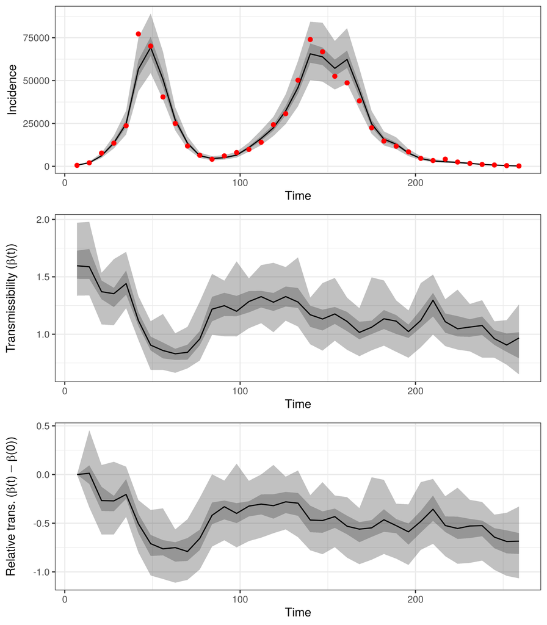

Model inference results. Top panel shows the GP consultation results, with the points showing the actual data points. The ribbons represent the 95%% and 50%% confidence interval in incidence and the black line shows the median. The middle panel shows the transmissibiltiy over time and the bottom panel the change in transmissibility relative to the starting transmissibility.

```r
model <- bi_model(lines = stringi::stri_split_lines(model_str)[[1]])
bi_model <- libbi(model)
input_lst <- list(N = 52196381)
end_time <- max(y$time)
obs_lst <- list(y = y %>% dplyr::filter(time <= end_time))

bi <- sample(bi_model, end_time = end_time, input = input_lst, obs = obs_lst, nsamples = 1000, nparticles = minParticles, nthreads = ncores, proposal = 'prior') %>%
  adapt_particles(min = minParticles, max = minParticles*200) %>%
  adapt_proposal(min = 0.05, max = 0.4) %>%
  sample(nsamples = 5000, thin = 5) %>% # burn in
  sample(nsamples = 5000, thin = 5)

bi_lst <- bi_read(bi %>% sample_obs)
```

# References

Dureau, Joseph, Konstantinos Kalogeropoulos, and Marc Baguelin. 2013. “Capturing the Time-Varying Drivers of an Epidemic Using Stochastic Dynamical Systems.” *Biostatistics* 14 (3): 541–55. https://doi.org/10.1093/biostatistics/kxs052.